# Part II - Airline Flight Data Analysis

## by Evans Addo-Sampong

## Investigation Overview

The focus of the exploratory analysis was on the airlines carriers.

Below are some few key insights that the anaylsis generated

## Dataset Overview

The dataset explored in this project is a flight data for 2008. The dataset is has about 2.3 million rows and 29 columns. It comtains about 2.3 million instances of data on flights for the year 2008. The data include such flight features  
as the month of the flight, day of the month of the flight, day of the week of the flight, carrirer (airline), flight destination, flight origin and flight delay factors/reasons. The dataset was obtained from [Havard Dataverse](https://dataverse.harvard.edu/dataset.xhtml?persistentId=doi:10.7910/DVN/HG7NV7#)

## Distribution of Flights Among Carriers

The dataset contained data on 20 different airlines carriers. These carriers shared about 2.3 million flights among them. The distribution of flights among the carries is visualized in the cells below.

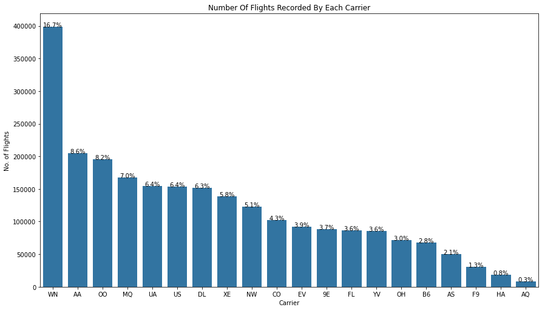

From the graph above, it can be observed that almost WN had the most flights recorded with a total of 16.7% of all flights recorded in 2008. This was followed by with a total of 8.6%. AQ had the least number of recorded flights with only 0.3% of the total flights recorded in 2008.

## Carries with the most Cancelled Flights

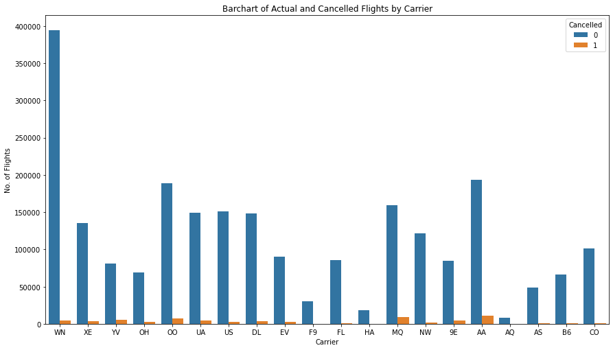

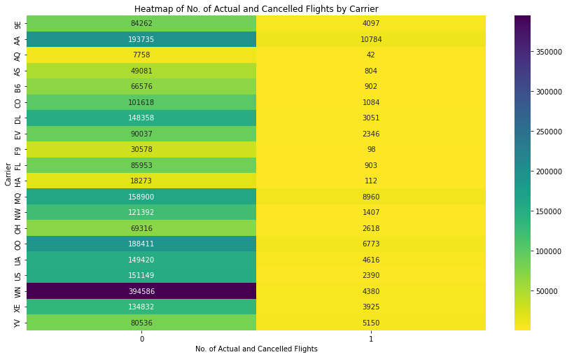

It can be obsereved from the visualizations above that although WN had the most number of flights in 2008, they recorded very low flight cancellations. AA had by far the most number of flight cancellations, recording 10,784 cancelled flights, followed by MQ with 8,960 cancelled flights.

## Which Carries Had the Most Diverted Flights

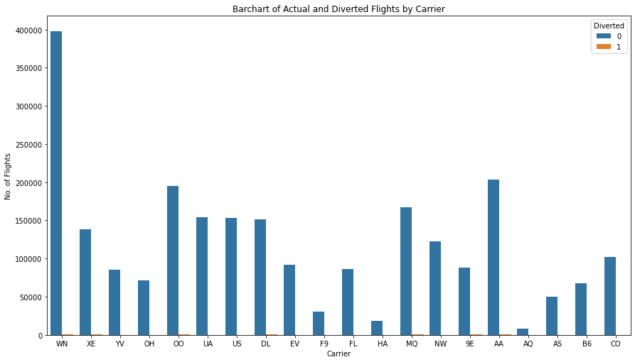

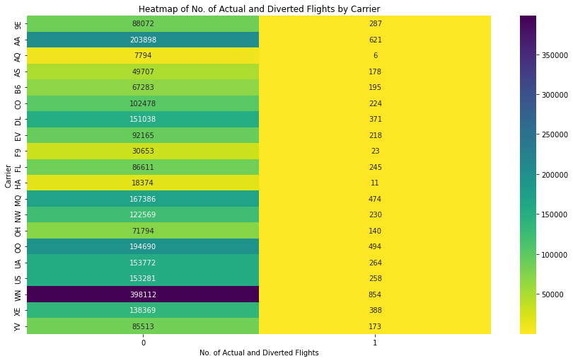

Even though WN had the most recorded flights, they also recorded the most diverted flights with 854 diverted flights. AQ had the least number of diverted flights in 2008.